# Co-diagnosis network analysis

```r
source(here("utils/data_processing.R"))
source(here("utils/figures.R"))
```

# Introduction

- Goal is to model diagnoses from each criteria based on how frequently they co-occur together within a single 10-point differential diagnosis iteration.
- The rationale is that an ideal set of criteria will tend to result in a relatively similar set of diagnoses in each iteration and thus a small set of highly co-occurring diagnoses.
- Conversely, a poor set of criteria will generate highly variable diagnoses in each iteration and rates of co-occurrence will be comparatively lower.

# Import and process data

```r
df_gpt3 <- read_csv(here("data/processed_diagnoses/diagnoses_gpt3.csv.gz"))
df_gpt4 <- read_csv(here("data/processed_diagnoses/diagnoses_gpt4.csv.gz"))
df_gpt4_icd <- read_csv(here("data/processed_diagnoses/diagnoses_gpt4_icd.csv.gz"))
```

```r
# Tally each pair of co-occuring diagnoses within each criteria
df_codiag_gpt3 <- create_codiagnosis_df(df_gpt3)
df_codiag_gpt4 <- create_codiagnosis_df(df_gpt4)
df_codiag_gpt4_icd <- create_codiagnosis_df(df_gpt4_icd)
```

```r
df_codiag_gpt4
```

| from | to | n | criteria | rank | freq |
| --- | --- | --- | --- | --- | --- |
| anaphylaxis | food allergy | 4211 | mcas_consortium | 1 | 0.0093636873 |
| anaphylaxis | hereditary angioedema | 3496 | mcas_consortium | 2 | 0.0077737950 |
| allergic reaction | anaphylaxis | 2680 | mcas_consortium | 3 | 0.0059593165 |
| anaphylaxis | carcinoid syndrome | 2358 | mcas_consortium | 4 | 0.0052433091 |
| anaphylaxis | vasovagal syncope | 2194 | mcas_consortium | 5 | 0.0048786345 |
| anaphylaxis | urticaria | 2191 | mcas_consortium | 6 | 0.0048719636 |
| food allergy | hereditary angioedema | 2025 | mcas_consortium | 7 | 0.0045028418 |
| anaphylaxis | drug allergy | 2009 | mcas_consortium | 8 | 0.0044672638 |
| anaphylaxis | irritable bowel syndrome | 1860 | mcas_consortium | 9 | 0.0041359436 |
| drug allergy | food allergy | 1832 | mcas_consortium | 10 | 0.0040736821 |

[output cut: 990 more lines]

# Graph visualization

### Exploring layouts

- To determine clearest visualization of nodes and edges

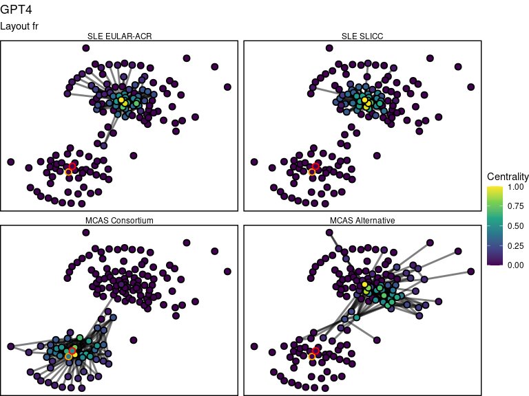

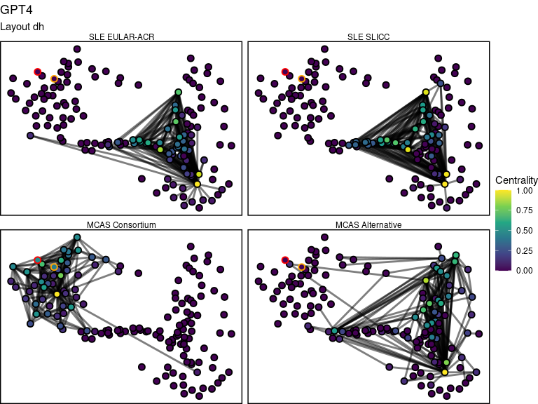

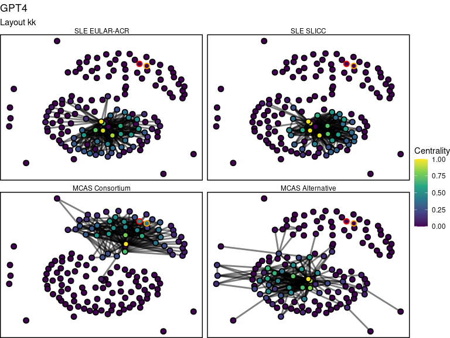

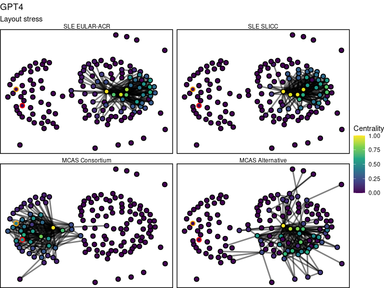

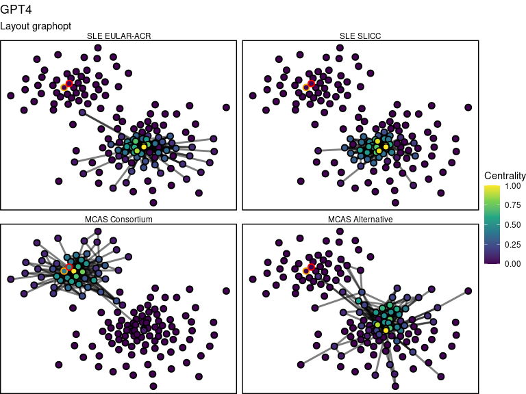

```r
# Selecting a layout
top_n <-  200
seed <- 1234

layouts <- c("fr", "dh", "kk", "stress", "graphopt")

graph_top_gpt4 <- make_codiagnosis_graph(df_codiag_gpt4, n_diagnoses = top_n)

for (l in layouts){
  set.seed(seed)
  plt <- centrality_graph(graph_top_gpt4, layout = l)
  plt <- plt + ggtitle("GPT4", subtitle = sprintf("Layout %s", l))
  print(plt)
}
```

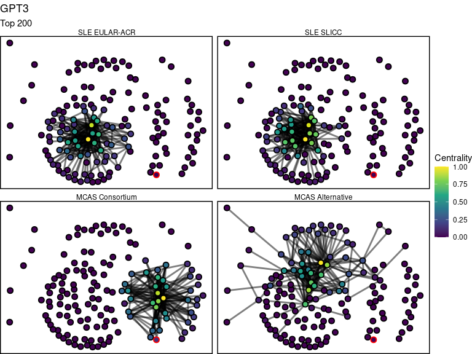

```r
top_n <-  200
seed <- 321
layout <- "stress"

graph_top_gpt3 <- make_codiagnosis_graph(df_codiag_gpt3, n_diagnoses = top_n)
graph_top_gpt4 <- make_codiagnosis_graph(df_codiag_gpt4, n_diagnoses = top_n)
graph_top_gpt4_icd <- make_codiagnosis_graph(df_codiag_gpt4_icd, n_diagnoses = top_n)

set.seed(seed);plt_graph_gpt3 <- centrality_graph(graph_top_gpt3, layout = layout); plt_graph_gpt3 + ggtitle("GPT3", subtitle = sprintf("Top %s", top_n))
```

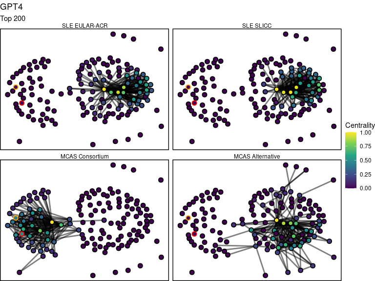

```r
set.seed(seed);plt_graph_gpt4 <- centrality_graph(graph_top_gpt4, layout = layout); plt_graph_gpt4 + ggtitle("GPT4", subtitle = sprintf("Top %s", top_n))
```

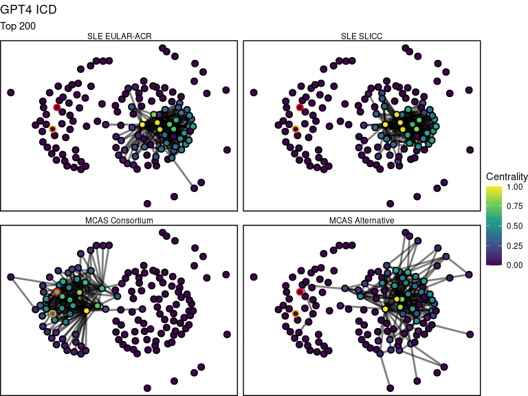

```r
set.seed(seed);plt_graph_gpt4icd <- centrality_graph(graph_top_gpt4_icd, layout = layout); plt_graph_gpt4icd + ggtitle("GPT4 ICD", subtitle = sprintf("Top %s", top_n))
```

# Evaluate edge density

- Edge density represents the total number of edges in a graph relative to the total number of **possible** edges in the graph
  - When all possible edges are present, edge density = 1
  - When no edges are present, edge density = 0
- Dense co-occurrence networks represent criteria that generate highly reproducible diagnoses. A sparse co-occurrence represents a high degree of variability

```r
# Run in script scripts/network_analysis/edge_density_ci.R
boot_graph_ci <- function(g, B, seed=NULL){
  if (!is.null(seed)){set.seed(seed)}
  g <- as_adjacency_matrix(g)
  g <- as.matrix(g)
  g <- snowboot::vertboot(g, boot_rep = B)
  g <- sapply(1:B, function(x) edge_density(graph_from_adjacency_matrix(g[[x]])))
  quantile(g, c(0.025, 0.5, 0.975))
}

# Calculate edge density 95% CI for each criteria
edge_density_boot <- function(df, replications = 100, seed = 1234){
  df_density <- df %>%
    ungroup() %>%
    select(criteria, from, to, weight = n, rank) %>%
    group_by(criteria) %>%
    nest() %>%
    mutate(boot = map(data, function(g){
      g <-  graph_from_data_frame(g, directed = F)
      out <- boot_graph_ci(g, B=replications, seed=seed)
      out["edge_density"] = edge_density(g)
      out
    })) %>%
    select(-data) %>%
    unnest_wider(boot)
  return(df_density)
}

edge_density_boot(df_codiag_gpt4, replications = 1000)
```

```r
edge_density_plot <- function(df){
  df %>%
    format_criteria() %>%
    ggplot(aes(x = criteria))+
    geom_point(aes(y=edge_density), color = "black")+
    geom_errorbar(aes(ymin = `2.5%`, ymax = `97.5%`), width = 0.4)+
    theme_bw()+
    theme(axis.text.x = element_text(angle = 45, hjust = 1)) +
    labs(x="", y="Edge density")
}
```

```
[1] "data/network_analysis/edge_density_boot_gpt3.csv"
[1] "data/network_analysis/edge_density_boot_gpt4.csv"
[1] "data/network_analysis/edge_density_boot_gpt4_icd.csv"
```

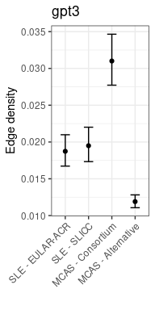

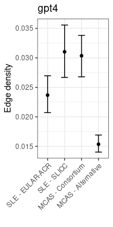

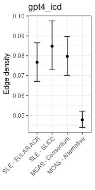

```r
models <- c("gpt3", "gpt4", "gpt4_icd")

for (m in models){
  path <- sprintf("data/network_analysis/edge_density_boot_%s.csv", m)
  print(path)
  plt <- read_csv(here(path)) %>%
    edge_density_plot()+
    ggtitle(m)
  print(plt)
}
```

### Permutation testing of edge density significance

```r
# Run in separate script source(here("scripts/network_analysis/edge_density_permutation.R"))
library(here)
source(here("utils/data_processing.R"))
source(here("utils/figures.R"))
library(future.apply)

threads <- 48
n_boot <- 500
model <- "gpt4"

read_path <- sprintf("data/processed_diagnoses/diagnoses_%s.csv.gz", model)
df <- read_csv(here(read_path))
df_codiag <- create_codiagnosis_df(df)

df_density <- df_codiag %>%
  ungroup() %>%
  select(criteria, from, to, weight = n, rank) %>%
  group_by(criteria) %>%
  nest() %>%
  mutate(data = map_dbl(data, function(g){
    g <-  graph_from_data_frame(g, directed = F)
    edge_density(g)
  })) %>%
  deframe()


difference_dist <- function(x){
  d <- dist(x, method = "manhattan")
  v <- as.dist(apply(combn(x, 2, simplify = T), 2, diff))
  d[1:length(v)] <- v
  broom::tidy(d)
}

criteria_levels <- c(
  "eular_acr_sle",
  "slicc_sle",
  "mcas_consortium",
  "mcas_alternative"
)

graph_permutation_diff <- function(){
  t(combn(c(
    "eular_acr_sle",
    "mcas_alternative",
    "mcas_consortium",
    "slicc_sle"),
    2)) %>%
    as.data.frame() %>%
    mutate(data = map2(V1, V2, function(x,y){
      filter(df, criteria == x | criteria == y) %>%
        mutate(diagnosis = sample(diagnosis, replace = F)) %>%
        create_codiagnosis_df()
    })) %>%
    mutate(data = map_dbl(data, function(d){
      ungroup(d) %>%
        select(criteria, from, to, weight = n, rank) %>%
        nest(.by = criteria) %>%
        mutate(data = map_dbl(data, ~edge_density(graph_from_data_frame(.)))) %>%
        deframe() %>% diff()
    })) %>%
    unite(comparison, V1, V2, sep = "__") %>%
    deframe()
}


plan(multisession, workers = threads)
permutation_data <- future_replicate(n = n_boot, graph_permutation_diff(), future.seed = 1234)

permutation_data <- as.data.frame(permutation_data) %>%
  rownames_to_column("pair") %>%
  separate(pair, into = c("item1", "item2"), sep = "__") %>%
  mutate(data = map2(item1, item2, ~sort(factor(c(.x,.y), levels = criteria_levels)))) %>%
  unnest_wider(data, names_sep = "") %>%
  mutate(reverse = item1 != data1) %>%
  unite(pair, data1, data2, sep = "__") %>%
  select(!contains("item")) %>%
  pivot_longer(!c(pair, reverse), names_to = "i", values_to = "difference") %>%
  mutate(difference = ifelse(reverse, -difference, difference)) %>%
  select(-reverse)

original_data <- difference_dist(df_density) %>%
  rename(difference = distance) %>%
  mutate_at(vars(c(item1, item2)), as.character) %>%
  mutate(data = map2(item1, item2, ~sort(factor(c(.x,.y), levels = criteria_levels)))) %>%
  unnest_wider(data, names_sep = "") %>%
  mutate(reverse = item1 != data1) %>%
  mutate(difference = ifelse(reverse, -difference, difference)) %>%
  unite(pair, data1, data2, sep = "__") %>%
  select(pair, difference)

permutation_plot_raw <- ggplot(permutation_data, aes(x = difference))+
  geom_histogram()+
  geom_vline(data = original_data, aes(xintercept = difference))+
  facet_wrap(~pair)+
  theme_bw()

permutation_plot_abs <- ggplot(permutation_data, aes(x = abs(difference)))+
  geom_histogram()+
  geom_vline(data = original_data, aes(xintercept = abs(difference)))+
  facet_wrap(~pair)+
  theme_bw()

permutation_significance_abs <- permutation_data %>%
  summarise(permutation = list(difference), .by = pair) %>%
  left_join(original_data) %>%
  mutate(
    abs_quantile = map2_dbl(difference, permutation, ~1-ecdf(abs(.y))(abs(.x)))
  ) %>%
  select(pair, abs_quantile)

output_list <- list(
  "original_data" = original_data,
  "permutation_data" = permutation_data,
  "permutation_significance_abs" = permutation_significance_abs,
  "permutation_plot_raw" = permutation_plot_raw,
  "permutation_plot_abs" = permutation_plot_abs
)

write_path <- sprintf("data/network_analysis/edge_density_permutation_%s.RDS", model)
saveRDS(output_list, here(write_path))
```

| pair | difference |
| --- | --- |
| mcas_consortium__mcas_alternative | -0.006679345 |
| eular_acr_sle__mcas_consortium | -0.000671640 |
| slicc_sle__mcas_consortium | -0.008325325 |
| eular_acr_sle__mcas_alternative | -0.015676310 |
| slicc_sle__mcas_alternative | -0.007350985 |
| eular_acr_sle__slicc_sle | 0.007350985 |

| pair | i | difference |
| --- | --- | --- |
| eular_acr_sle__mcas_alternative | V1 | -1.303696e-04 |
| eular_acr_sle__mcas_alternative | V2 | 1.609089e-04 |
| eular_acr_sle__mcas_alternative | V3 | -1.103415e-04 |
| eular_acr_sle__mcas_alternative | V4 | -1.155243e-04 |
| eular_acr_sle__mcas_alternative | V5 | -1.406905e-04 |
| eular_acr_sle__mcas_alternative | V6 | -2.039432e-05 |
| eular_acr_sle__mcas_alternative | V7 | -3.325479e-04 |
| eular_acr_sle__mcas_alternative | V8 | 3.936720e-04 |
| eular_acr_sle__mcas_alternative | V9 | 2.628055e-04 |
| eular_acr_sle__mcas_alternative | V10 | 1.553883e-04 |

[output cut: 990 more lines]

| pair | abs_quantile |
| --- | --- |
| eular_acr_sle__mcas_alternative | 0.000 |
| eular_acr_sle__mcas_consortium | 0.152 |
| eular_acr_sle__slicc_sle | 0.000 |
| mcas_consortium__mcas_alternative | 0.000 |
| slicc_sle__mcas_alternative | 0.000 |
| slicc_sle__mcas_consortium | 0.000 |

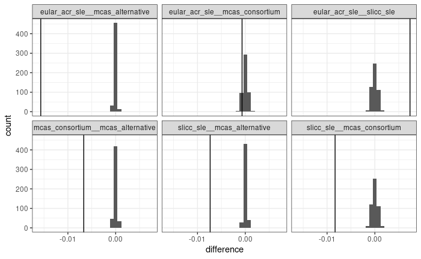

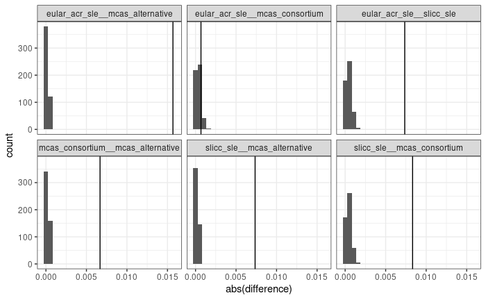

```r
readRDS(here("data/network_analysis/edge_density_permutation_gpt4.RDS"))
```

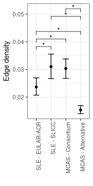

```r
# Combining permutation p-values with edge density mean-CI plot
edge_density_sig_plot <- function(ci_df, permutation_df=NULL){
  stat_test_template <- ci_df %>%
    format_criteria() %>%
    mutate(criteria = as.character(criteria)) %>%
    pivot_longer(-criteria, names_to = "name", values_to = "edge_density") %>%
    rstatix::t_test(edge_density ~ criteria) %>%
    rstatix::add_xy_position() %>%
    sort_paired_columns(prefix = "group")

  permutation_df <- permutation_df %>%
    separate(pair, into = c("group1", "group2"), sep = "__") %>%
    rename(p = abs_quantile) %>%
    mutate(index = 1:n()) %>%
    pivot_longer(-c(p, index), names_to = "group", values_to = "criteria") %>%
    format_criteria() %>%
    pivot_wider(names_from = "group", values_from = "criteria") %>%
    select(-index) %>%
    sort_paired_columns(prefix = "group")

  stat_test <- stat_test_template %>%
    select(-p, -p.adj, -p.adj.signif) %>%
    left_join(permutation_df, by = c("group1", "group2")) %>%
    mutate(p.adj = p.adjust(p, method = "BH")) %>%
    mutate(p.adj.signif = ifelse(p.adj <= 0.05, "*", "ns"))

  ci_df %>%
    format_criteria() %>%
    ggplot(aes(x = criteria))+
    geom_point(aes(y=edge_density), color = "black")+
    geom_errorbar(aes(ymin = `2.5%`, ymax = `97.5%`), width = 0.4)+
    ggpubr::stat_pvalue_manual(data = stat_test, hide.ns = T)+
    theme_bw()+
    theme(axis.text.x = element_text(angle = 90, hjust = 1)) +
    labs(x="", y="Edge density")
}

plt_density_gpt4 <- edge_density_sig_plot(
  ci_df = read_csv(here("data/network_analysis/edge_density_boot_gpt4.csv")),
  permutation_df = readRDS(here("data/network_analysis/edge_density_permutation_gpt4.RDS")) %>%
    .$permutation_significance_abs
)
plt_density_gpt4
```

# Plot centrality

```r
calculate_subgraph_centrality <- function(g, centrality_fun = "centrality_eigen"){
  data.frame(criteria = g %>% activate(edges) %>% pull(criteria) %>% unique()) %>%
    mutate(sub_graphs = map(criteria, function(c){
      g %>% as_data_frame() %>% filter(criteria == c) %>% as_tbl_graph(directed = F) %>%
        activate(nodes) %>% mutate(centrality = get(centrality_fun)()) %>% data.frame()
    })) %>%
  unnest(sub_graphs) %>%
  pivot_wider(names_from = "name", values_from = "centrality", values_fill = 0) %>%
  column_to_rownames("criteria")
}

graph_all_gpt4 <- make_codiagnosis_graph(df_codiag_gpt4, n_diagnoses = top_n)
df_centr_gpt4 <- calculate_subgraph_centrality(graph_all_gpt4)
```

```r
df_centr_gpt4 %>%
  rownames_to_column("criteria") %>%
  format_criteria() %>%
  column_to_rownames("criteria") %>%
  as.matrix() %>%
  t() %>%
  lsa::cosine()
```

```
                   MCAS - Consortium MCAS - Alternative SLE - EULAR-ACR SLE - SLICC
MCAS - Consortium        1.000000000         0.05260835      0.01460527 0.009231271
MCAS - Alternative       0.052608350         1.00000000      0.53900046 0.544665093
SLE - EULAR-ACR          0.014605268         0.53900046      1.00000000 0.859811368
SLE - SLICC              0.009231271         0.54466509      0.85981137 1.000000000
```

```r
custom_heatmap <- function(data,
                           title,
                           metric,
                           color_scale = hcl.colors(3, "Earth"),
                           midpoint = NULL,
                           symmetric = T,
                           font_size=10,
                           dendrogram_weight = unit(10, "mm"),
                           legend_params = list(NULL)){
  scale_max <- ifelse(symmetric,max(abs(data)),max(data))
  scale_min <- ifelse(symmetric,-max(abs(data)),min(data))
  scale_mid <- scale_min + (scale_max - scale_min)/2

  midpoint <- ifelse(is.null(midpoint), scale_mid, midpoint)

  color_function <-circlize::colorRamp2(c(scale_min,midpoint,scale_max), color_scale)

  legend_params <- append(
    list(
      title_gp = gpar(fontsize = font_size),
      labels_gp = gpar(fontsize = font_size*0.8)),
    legend_params)

  ComplexHeatmap::Heatmap(
    data,
    col = color_function,
    rect_gp = grid::gpar(col = "black", lwd = 1),
    column_title = title,
    name = metric,
    row_names_gp = grid::gpar(fontsize = font_size),
    column_names_gp = grid::gpar(fontsize = font_size),
    column_dend_height  = dendrogram_weight,
    row_dend_width = dendrogram_weight,
    heatmap_legend_param = legend_params
  )
}
```

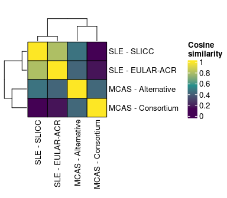

```r
cp_font <- 9
plt_heat_all <- df_codiag_gpt4 %>%
  make_codiagnosis_graph() %>%
  calculate_subgraph_centrality() %>%
  rownames_to_column("criteria") %>%
  format_criteria() %>%
  column_to_rownames("criteria") %>%
  as.matrix() %>%
  t() %>%
  lsa::cosine() %>%
  custom_heatmap(color_scale = viridis::viridis(3), title = " ", metric = "Cosine\nsimilarity", symmetric = F)
plt_heat_all
```

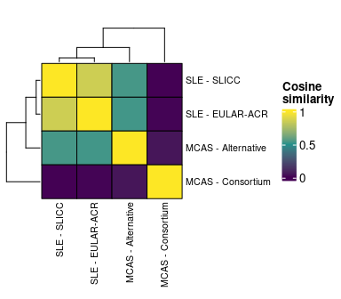

```r
plt_heat_top <- df_centr_gpt4 %>%
  rownames_to_column("criteria") %>%
  format_criteria() %>%
  column_to_rownames("criteria") %>%
  as.matrix() %>%
  t() %>%
  lsa::cosine() %>%
  custom_heatmap(color_scale = viridis::viridis(3), title = " ", metric = "Cosine\nsimilarity", symmetric = F,
                 font_size = 8
                 )
plt_heat_top
```

# Final plot

```r
set.seed(1234);plt_graph_gpt4 <- centrality_graph(
  graph_top_gpt4,
  layout = "stress",
  point_size = 2,
  border_size = 0.5,
  edge_width = 0.5,
  edge_alpha = 0.75)


plt_fig <- cowplot::plot_grid(
  cowplot::plot_grid(
    NULL, plt_graph_gpt4, nrow=1, rel_widths=c(0.05,0.9), labels = c("A","")
  ),
  NULL,
  cowplot::plot_grid(
    plt_density_gpt4,
    NULL,
    grid::grid.grabExpr(ComplexHeatmap::draw(plt_heat_all)),
    nrow = 1,
    rel_widths = c(0.3,0.05,0.7),
    labels = c("B","","C")
  ),

  ncol = 1,
  rel_heights = c(1,0.05,0.8)
)
```

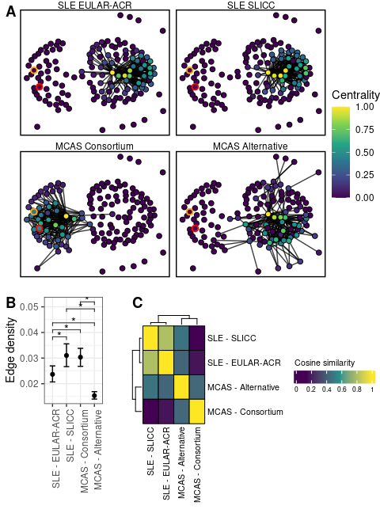

```r
plt_fig
```

```r
set.seed(1234);plt_graph_gpt4 <- centrality_graph(
  graph_top_gpt4,
  layout = "stress",
  point_size = 1.25,
  border_size = 0.25,
  edge_width = 0.5,
  edge_alpha = 0.5,
  label_text_size = 9,
  tick_text_size = 6,
  highlight_stroke_multiplier = 3,
  legend_height = unit(35, "pt"),
  legend_width = unit(10, "pt"))

plt_density_gpt4 <- edge_density_sig_plot(
  ci_df = read_csv(here("data/network_analysis/edge_density_boot_gpt4.csv")),
  permutation_df = readRDS(here("data/network_analysis/edge_density_permutation_gpt4.RDS")) %>%
    .$permutation_significance_abs
) + theme(
  axis.text.y = element_text(size=7),
  axis.title.y = element_text(size=9))
plt_heat_all <- df_codiag_gpt4 %>%
  make_codiagnosis_graph() %>%
  calculate_subgraph_centrality() %>%
  rownames_to_column("criteria") %>%
  format_criteria() %>%
  column_to_rownames("criteria") %>%
  as.matrix() %>%
  t() %>%
  lsa::cosine() %>%
  custom_heatmap(color_scale = viridis::viridis(3),
                 title = " ",
                 metric = "Cosine similarity",
                 symmetric = F,
                 font_size = 8,
                 dendrogram_weight = unit(3, "mm"),
                 legend_params = list(
    legend_height = unit(5, 'cm'),
    direction = "horizontal"
  ))


plt_fig <- cowplot::plot_grid(
  NULL,
  cowplot::plot_grid(
    NULL, plt_graph_gpt4, nrow=1, rel_widths=c(0.05,0.9)
  ),
  NULL,
  cowplot::plot_grid(
    plot_grid(NULL, plt_density_gpt4 ,rel_heights = c(0.1, 1), ncol = 1),
    NULL,
    grid::grid.grabExpr(ComplexHeatmap::draw(plt_heat_all, heatmap_legend_side = "bottom")),
    nrow = 1,
    rel_widths = c(0.4,0.05,0.7),
    labels = c("B","","C"),
    axis = 'h', align = 'bt'
  ),

  ncol = 1,
  rel_heights = c(0.05, 1, 0.01, 1),
  labels = c("A")
)
```

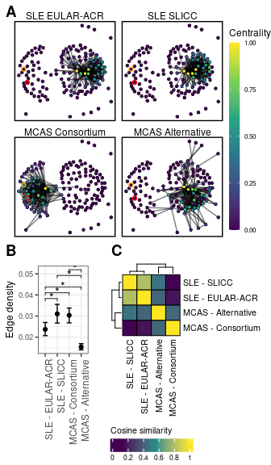

```r
plt_fig
```

```r
ggsave(here("figures/5_Network_analysis.pdf"), plot=plt_fig, height = 6, width = 3.5)
```